# 01 — Baseline and Tuning

Claude vs Gemini on three Level 1 subagents: what the baseline measured, and what the ablation ladder bought.

**This notebook displays; it does not compute.** Every table and chart comes out of `amw.reporting.notebook` over an artifact written by `cli.py`. If a cell here looks like it is doing analysis, that is a bug — the analysis belongs in the library where it can be tested.

Read the banner in the next output before reading any number below it.

```python
# papermill parameters
MODE = "replay"          # replay | hybrid | live
CUSTOMER = "demo_patents"
LIVE_CASES = 10          # size of the one live cell at the bottom
```

```python
%matplotlib inline
# the inline backend renders figures to PNG with no display attached, which is
# what papermill needs; `matplotlib.use("Agg")` would run headless too but would
# emit `<Figure ...>` text instead of a chart.

from IPython.display import Markdown, display

from amw.agents.schemas import SUBAGENTS
from amw.config import load_all
from amw.reporting import notebook as nb

cfg = load_all(customer=CUSTOMER)
phase2 = nb.load_phase2()
display(Markdown(f"**{nb.replay_banner(phase2)}**"))
```

**REPLAY — every number below comes from model calls recorded 2026-08-09T16:07:15+00:00 to 2026-08-10T02:45:59+00:00, not from a run just now.**

## 1. Deterministic metrics

No judge involved: exact match, F1, and schema validity computed against the gold references in the dataset. These are the numbers that do not depend on anyone's opinion, which is why they come first.

```python
metrics = nb.metrics_frame(phase2)
display(metrics[nb.METRIC_COLUMNS])
```

|  | subagent | variant | model | metric | point | lo | hi | n |
| --- | --- | --- | --- | --- | --- | --- | --- | --- |
| 0 | query_rewriter | claude_baseline | claude-sonnet | exact_match_intent | 0.728571 | 0.628571 | 0.828571 | 70 |
| 1 | query_rewriter | claude_baseline | claude-sonnet | filter_f1 | 0.973333 | 0.926667 | 1.000000 | 50 |
| 2 | query_rewriter | claude_baseline | claude-sonnet | filter_precision | 0.915094 | 0.839623 | 0.981132 | 53 |
| 3 | query_rewriter | claude_baseline | claude-sonnet | filter_recall | 0.753846 | 0.646154 | 0.861538 | 65 |
| 4 | query_rewriter | claude_baseline | claude-sonnet | json_schema_validity | 0.814286 | 0.714286 | 0.900000 | 70 |
| 5 | query_rewriter | gemini_naive | gemini-flash | exact_match_intent | 0.571429 | 0.457143 | 0.685714 | 70 |
| 6 | query_rewriter | gemini_naive | gemini-flash | filter_f1 | 0.950000 | 0.908974 | 0.981410 | 65 |
| 7 | query_rewriter | gemini_naive | gemini-flash | filter_precision | 0.914179 | 0.854431 | 0.964552 | 67 |
| 8 | query_rewriter | gemini_naive | gemini-flash | filter_recall | 0.965385 | 0.926923 | 0.992308 | 65 |
| 9 | query_rewriter | gemini_naive | gemini-flash | json_schema_validity | 0.971429 | 0.928571 | 1.000000 | 70 |
| 10 | query_rewriter | gemini_tuned_v1 | gemini-flash | exact_match_intent | 0.814286 | 0.714286 | 0.900000 | 70 |
| 11 | query_rewriter | gemini_tuned_v1 | gemini-flash | filter_f1 | 0.950000 | 0.917949 | 0.977564 | 65 |
| 12 | query_rewriter | gemini_tuned_v1 | gemini-flash | filter_precision | 0.914179 | 0.858209 | 0.962687 | 67 |
| 13 | query_rewriter | gemini_tuned_v1 | gemini-flash | filter_recall | 0.965385 | 0.936538 | 0.988462 | 65 |
| 14 | query_rewriter | gemini_tuned_v1 | gemini-flash | json_schema_validity | 1.000000 | 1.000000 | 1.000000 | 70 |
| 15 | chunk_summarizer | claude_baseline | claude-sonnet | citation_coverage | 1.000000 | 1.000000 | 1.000000 | 68 |
| 16 | chunk_summarizer | claude_baseline | claude-sonnet | fabricated_citation_rate | 0.000000 | 0.000000 | 0.000000 | 68 |
| 17 | chunk_summarizer | claude_baseline | claude-sonnet | json_schema_validity | 0.971429 | 0.928571 | 1.000000 | 70 |
| 18 | chunk_summarizer | claude_baseline | claude-sonnet | uncited_claim_rate | 0.000000 | 0.000000 | 0.000000 | 68 |
| 19 | chunk_summarizer | gemini_naive | gemini-flash | citation_coverage | 0.940299 | 0.880597 | 0.985075 | 67 |
| 20 | chunk_summarizer | gemini_naive | gemini-flash | fabricated_citation_rate | 0.000000 | 0.000000 | 0.000000 | 63 |
| 21 | chunk_summarizer | gemini_naive | gemini-flash | json_schema_validity | 0.942857 | 0.885714 | 0.985714 | 70 |
| 22 | chunk_summarizer | gemini_naive | gemini-flash | uncited_claim_rate | 0.000000 | 0.000000 | 0.000000 | 63 |
| 23 | chunk_summarizer | gemini_tuned_v1 | gemini-flash | citation_coverage | 1.000000 | 1.000000 | 1.000000 | 70 |
| 24 | chunk_summarizer | gemini_tuned_v1 | gemini-flash | fabricated_citation_rate | 0.000000 | 0.000000 | 0.000000 | 70 |
| 25 | chunk_summarizer | gemini_tuned_v1 | gemini-flash | json_schema_validity | 1.000000 | 1.000000 | 1.000000 | 70 |
| 26 | chunk_summarizer | gemini_tuned_v1 | gemini-flash | uncited_claim_rate | 0.000000 | 0.000000 | 0.000000 | 70 |
| 27 | feature_extractor | claude_baseline | claude-sonnet | answered_precision | 1.000000 | 1.000000 | 1.000000 | 66 |
| 28 | feature_extractor | claude_baseline | claude-sonnet | extraction_accuracy | 0.971429 | 0.928571 | 1.000000 | 70 |
| 29 | feature_extractor | claude_baseline | claude-sonnet | hallucination_rate | 0.000000 | 0.000000 | 0.000000 | 33 |
| 30 | feature_extractor | claude_baseline | claude-sonnet | json_schema_validity | 0.957143 | 0.900000 | 1.000000 | 70 |
| 31 | feature_extractor | claude_baseline | claude-sonnet | omission_rate | 0.029412 | 0.000000 | 0.073529 | 68 |
| 32 | feature_extractor | gemini_naive | gemini-flash | answered_precision | 1.000000 | 1.000000 | 1.000000 | 68 |
| 33 | feature_extractor | gemini_naive | gemini-flash | extraction_accuracy | 1.000000 | 1.000000 | 1.000000 | 70 |
| 34 | feature_extractor | gemini_naive | gemini-flash | hallucination_rate | 0.000000 | 0.000000 | 0.000000 | 33 |
| 35 | feature_extractor | gemini_naive | gemini-flash | json_schema_validity | 1.000000 | 1.000000 | 1.000000 | 70 |
| 36 | feature_extractor | gemini_naive | gemini-flash | omission_rate | 0.000000 | 0.000000 | 0.000000 | 68 |
| 37 | feature_extractor | gemini_tuned_v1 | gemini-flash | answered_precision | 1.000000 | 1.000000 | 1.000000 | 68 |
| 38 | feature_extractor | gemini_tuned_v1 | gemini-flash | extraction_accuracy | 1.000000 | 1.000000 | 1.000000 | 70 |
| 39 | feature_extractor | gemini_tuned_v1 | gemini-flash | hallucination_rate | 0.000000 | 0.000000 | 0.000000 | 33 |
| 40 | feature_extractor | gemini_tuned_v1 | gemini-flash | json_schema_validity | 1.000000 | 1.000000 | 1.000000 | 70 |
| 41 | feature_extractor | gemini_tuned_v1 | gemini-flash | omission_rate | 0.000000 | 0.000000 | 0.000000 | 68 |

### Schema validity, and the one thing you must say out loud about it

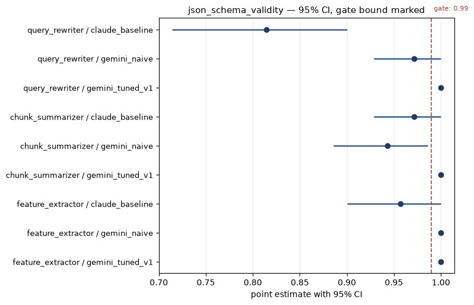

> **On every Claude figure above:** tool-use JSON; native structured outputs unavailable under this org's policy — not the model's ceiling.

```python
schema = metrics[metrics["metric"] == "json_schema_validity"]
fig = nb.interval_chart(
    schema,
    label=["subagent", "variant"],
    title="json_schema_validity — 95% CI, gate bound marked",
    bound=cfg.gates.subagent_gates["json_schema_validity"].min,
    bound_label="gate",
)
display(fig)

from amw.reporting import CLAUDE_SCHEMA_CAVEAT
display(Markdown(f"> **On every Claude figure above:** {CLAUDE_SCHEMA_CAVEAT}"))
```

## 2. Judge scores

Rubric-anchored, k=2 repeats, bootstrap CIs.

**`judged_n` and `split` are part of the number.** Feature Extractor was judged on all 70 items; the other two on the 28-item core split. A judge column read without those two columns compares two different measurements.

|  | subagent | variant | model | point | lo | hi | n | status | judged_n | split | repeats | full_agreement_rate |
| --- | --- | --- | --- | --- | --- | --- | --- | --- | --- | --- | --- | --- |
| 0 | query_rewriter | claude_baseline | claude-sonnet | 0.910714 | 0.839286 | 0.964286 | 28 | measured | 28 | core | 2 | 1.000000 |
| 1 | query_rewriter | gemini_naive | gemini-flash | 0.835714 | 0.787500 | 0.885714 | 28 | measured | 28 | core | 2 | 1.000000 |
| 2 | query_rewriter | gemini_tuned_v1 | gemini-flash | 0.851786 | 0.796429 | 0.905357 | 28 | measured | 28 | core | 2 | 1.000000 |
| 3 | chunk_summarizer | claude_baseline | claude-sonnet | 0.901786 | 0.830357 | 0.955580 | 28 | measured | 28 | core | 2 | 1.000000 |
| 4 | chunk_summarizer | gemini_naive | gemini-flash | 0.897321 | 0.830357 | 0.955357 | 28 | measured | 28 | core | 2 | 0.964286 |
| 5 | chunk_summarizer | gemini_tuned_v1 | gemini-flash | 0.915179 | 0.870536 | 0.955357 | 28 | measured | 28 | core | 2 | 0.964286 |
| 6 | feature_extractor | claude_baseline | claude-sonnet | 0.899626 | 0.867890 | 0.928707 | 70 | measured | 70 | all | 2 | 0.828571 |
| 7 | feature_extractor | gemini_naive | gemini-flash | 0.821293 | 0.787109 | 0.853571 | 70 | measured | 70 | all | 2 | 0.814286 |
| 8 | feature_extractor | gemini_tuned_v1 | gemini-flash | 0.795272 | 0.760372 | 0.827655 | 70 | measured | 70 | all | 2 | 0.800000 |

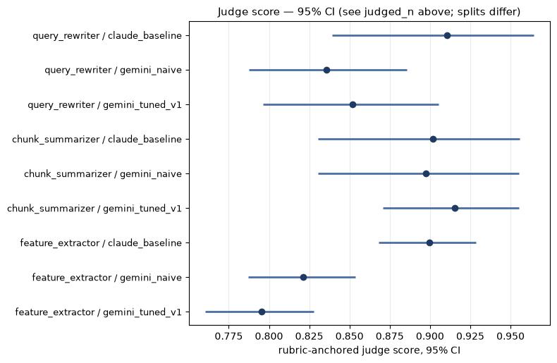

```python
judges = nb.judge_frame(phase2)
display(judges)

fig = nb.interval_chart(
    judges,
    label=["subagent", "variant"],
    title="Judge score — 95% CI (see judged_n above; splits differ)",
    xlabel="rubric-anchored judge score, 95% CI",
)
display(fig)
```

## 3. The ablation ladder

What did each prompt change actually buy? Each rung runs through the *same* scoring path as the baseline, so the rungs are comparable to each other and to the baseline's **core-split** judge numbers — not to the 70-item column above.

Rungs nobody has run stay in the table with `rung_status = no_recordings` and no numbers. They are hypotheses, and a ladder that hid them would read as a ladder that had been fully climbed.

```python
ladders = {s: nb.load_ablation(s) for s in SUBAGENTS}
for subagent, result in ladders.items():
    display(Markdown(f"**{subagent}**"))
    display(nb.ablation_frame(result)[nb.LADDER_COLUMNS])
```

**query_rewriter**

|  | rung | variant | output_mode | branches_from | metric | point | lo | hi | judged_n | rung_status |
| --- | --- | --- | --- | --- | --- | --- | --- | --- | --- | --- |
| 0 | baseline | claude_baseline | tool | NaN | judge_score | 0.910714 | 0.839286 | 0.964286 | 28 | measured |
| 1 | A0 | gemini_naive | tool | NaN | judge_score | 0.835714 | 0.787500 | 0.885714 | 28 | measured |
| 2 | A1-A3 | gemini_tuned_v1 | response_schema | A0 | judge_score | 0.851786 | 0.796429 | 0.905357 | 28 | measured |

**chunk_summarizer**

|  | rung | variant | output_mode | branches_from | metric | point | lo | hi | judged_n | rung_status |
| --- | --- | --- | --- | --- | --- | --- | --- | --- | --- | --- |
| 0 | baseline | claude_baseline | tool | NaN | judge_score | 0.901786 | 0.830357 | 0.955580 | 28 | measured |
| 1 | A0 | gemini_naive | tool | NaN | judge_score | 0.897321 | 0.830357 | 0.955357 | 28 | measured |
| 2 | A1-A3 | gemini_tuned_v1 | response_schema | A0 | judge_score | 0.915179 | 0.870536 | 0.955357 | 28 | measured |

**feature_extractor**

|  | rung | variant | output_mode | branches_from | metric | point | lo | hi | judged_n | rung_status |
| --- | --- | --- | --- | --- | --- | --- | --- | --- | --- | --- |
| 0 | baseline | claude_baseline | tool | NaN | judge_score | 0.903486 | 0.857143 | 0.946429 | 28.0 | measured |
| 1 | A0 | gemini_naive | tool | NaN | judge_score | 0.837160 | 0.790806 | 0.882239 | 28.0 | measured |
| 2 | A1-A3 | gemini_tuned_v1 | response_schema | A0 | judge_score | 0.806548 | 0.755527 | 0.852891 | 28.0 | measured |
| 3 | A0-schema | gemini_naive_schema | response_schema | A0 | not measured | NaN | NaN | NaN | NaN | no_recordings |
| 4 | A4-novelty-tool | gemini_novelty_v1_tool | tool | A0 | not measured | NaN | NaN | NaN | NaN | no_recordings |
| 5 | A4-novelty-schema | gemini_novelty_v1_schema | response_schema | A4-novelty-tool | not measured | NaN | NaN | NaN | NaN | no_recordings |

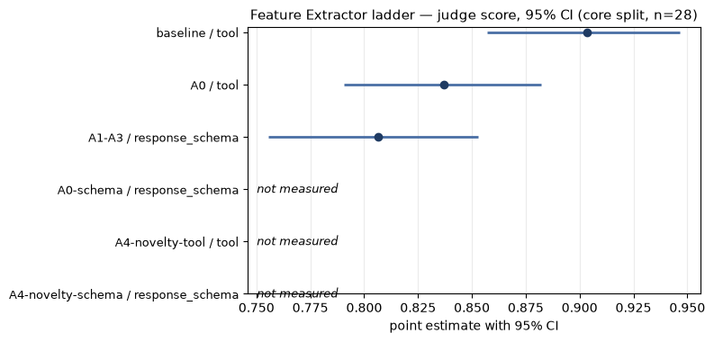

```python
fe = nb.ablation_frame(ladders["feature_extractor"])
display(
    nb.interval_chart(
        fe,
        label=["rung", "output_mode"],
        title="Feature Extractor ladder — judge score, 95% CI (core split, n=28)",
    )
)
```

### What the ladder is telling us, and what it is not

Two things to read off the Feature Extractor table before drawing a conclusion:

- **A1–A3 is one bundled rung.** Prompt wording and output mode changed together, so the drop cannot be attributed to either alone. The `A0-schema` and `A4-novelty-*` rungs exist precisely to separate them, and they are unmeasured.
- **`leaked_example_items`** flags any rung whose worked example is itself a scored item. Where it is non-empty, that rung's number is optimistic by an unknown amount.

```python
for subagent, result in ladders.items():
    frame = nb.ablation_frame(result)
    leaked = frame[frame["leaked_example_items"] != ""]
    for _, row in leaked.iterrows():
        print(f"{subagent}/{row['rung']}: worked example is a scored item — {row['leaked_example_items']}")
    for note in result.notes:
        print(f"{subagent}: {note}")
```

```
feature_extractor/A4-novelty-tool: worked example is a scored item — fe-0003
feature_extractor/A4-novelty-schema: worked example is a scored item — fe-0003
feature_extractor: rung A4-novelty-tool: its prompt quotes fe-0003 as a worked example and those items are also in the scored split. Its judged score is optimistic on them by construction. Not excluded — that would change this rung's denominator only.
feature_extractor: rung A4-novelty-schema: its prompt quotes fe-0003 as a worked example and those items are also in the scored split. Its judged score is optimistic on them by construction. Not excluded — that would change this rung's denominator only.
feature_extractor: rung(s) A0-schema, A4-novelty-tool, A4-novelty-schema have no recorded calls in mode 'replay' and carry no numbers. Run them live to measure them.
```

## 4. One live cell

Everything above is replay. This cell is the live proof, parameterized by `MODE`: in `replay` it resolves from recordings and makes zero calls; set `MODE="hybrid"` or `"live"` and the same code path makes real ones. Same function `cli.py phase2` calls — a demo that exercised a different path would prove nothing about the path a customer will use.

```python
from amw.eval.runner import run_phase2

live = run_phase2(config=cfg, mode=MODE, n=LIVE_CASES, run_judge=False, write=False)
display(Markdown(f"**{nb.replay_banner(live)}**"))
display(nb.metrics_frame(live)[nb.METRIC_COLUMNS])
print(f"call errors: {sum(arm.calls_error for arm in live.arms)}")
```

**REPLAY — every number below comes from model calls recorded 2026-08-09T16:07:18+00:00 to 2026-08-10T02:07:45+00:00, not from a run just now.**

|  | subagent | variant | model | metric | point | lo | hi | n |
| --- | --- | --- | --- | --- | --- | --- | --- | --- |
| 0 | query_rewriter | claude_baseline | claude-sonnet | exact_match_intent | 0.800000 | 0.500000 | 1.0 | 10 |
| 1 | query_rewriter | claude_baseline | claude-sonnet | filter_f1 | 1.000000 | 1.000000 | 1.0 | 8 |
| 2 | query_rewriter | claude_baseline | claude-sonnet | filter_precision | 1.000000 | 1.000000 | 1.0 | 8 |
| 3 | query_rewriter | claude_baseline | claude-sonnet | filter_recall | 0.800000 | 0.500000 | 1.0 | 10 |
| 4 | query_rewriter | claude_baseline | claude-sonnet | json_schema_validity | 0.900000 | 0.700000 | 1.0 | 10 |
| 5 | query_rewriter | gemini_naive | gemini-flash | exact_match_intent | 0.600000 | 0.300000 | 0.9 | 10 |
| 6 | query_rewriter | gemini_naive | gemini-flash | filter_f1 | 0.954167 | 0.883333 | 1.0 | 10 |
| 7 | query_rewriter | gemini_naive | gemini-flash | filter_precision | 0.937500 | 0.837500 | 1.0 | 10 |
| 8 | query_rewriter | gemini_naive | gemini-flash | filter_recall | 0.987500 | 0.962500 | 1.0 | 10 |
| 9 | query_rewriter | gemini_naive | gemini-flash | json_schema_validity | 1.000000 | 1.000000 | 1.0 | 10 |
| 10 | query_rewriter | gemini_tuned_v1 | gemini-flash | exact_match_intent | 0.800000 | 0.500000 | 1.0 | 10 |
| 11 | query_rewriter | gemini_tuned_v1 | gemini-flash | filter_f1 | 0.966667 | 0.900000 | 1.0 | 10 |
| 12 | query_rewriter | gemini_tuned_v1 | gemini-flash | filter_precision | 0.950000 | 0.850000 | 1.0 | 10 |
| 13 | query_rewriter | gemini_tuned_v1 | gemini-flash | filter_recall | 1.000000 | 1.000000 | 1.0 | 10 |
| 14 | query_rewriter | gemini_tuned_v1 | gemini-flash | json_schema_validity | 1.000000 | 1.000000 | 1.0 | 10 |
| 15 | chunk_summarizer | claude_baseline | claude-sonnet | citation_coverage | 1.000000 | 1.000000 | 1.0 | 10 |
| 16 | chunk_summarizer | claude_baseline | claude-sonnet | fabricated_citation_rate | 0.000000 | 0.000000 | 0.0 | 10 |
| 17 | chunk_summarizer | claude_baseline | claude-sonnet | json_schema_validity | 1.000000 | 1.000000 | 1.0 | 10 |
| 18 | chunk_summarizer | claude_baseline | claude-sonnet | uncited_claim_rate | 0.000000 | 0.000000 | 0.0 | 10 |
| 19 | chunk_summarizer | gemini_naive | gemini-flash | citation_coverage | 1.000000 | 1.000000 | 1.0 | 9 |
| 20 | chunk_summarizer | gemini_naive | gemini-flash | fabricated_citation_rate | 0.000000 | 0.000000 | 0.0 | 9 |
| 21 | chunk_summarizer | gemini_naive | gemini-flash | json_schema_validity | 1.000000 | 1.000000 | 1.0 | 10 |
| 22 | chunk_summarizer | gemini_naive | gemini-flash | uncited_claim_rate | 0.000000 | 0.000000 | 0.0 | 9 |
| 23 | chunk_summarizer | gemini_tuned_v1 | gemini-flash | citation_coverage | 1.000000 | 1.000000 | 1.0 | 10 |
| 24 | chunk_summarizer | gemini_tuned_v1 | gemini-flash | fabricated_citation_rate | 0.000000 | 0.000000 | 0.0 | 10 |
| 25 | chunk_summarizer | gemini_tuned_v1 | gemini-flash | json_schema_validity | 1.000000 | 1.000000 | 1.0 | 10 |
| 26 | chunk_summarizer | gemini_tuned_v1 | gemini-flash | uncited_claim_rate | 0.000000 | 0.000000 | 0.0 | 10 |
| 27 | feature_extractor | claude_baseline | claude-sonnet | answered_precision | 1.000000 | 1.000000 | 1.0 | 9 |
| 28 | feature_extractor | claude_baseline | claude-sonnet | extraction_accuracy | 1.000000 | 1.000000 | 1.0 | 10 |
| 29 | feature_extractor | claude_baseline | claude-sonnet | hallucination_rate | 0.000000 | 0.000000 | 0.0 | 4 |
| 30 | feature_extractor | claude_baseline | claude-sonnet | json_schema_validity | 1.000000 | 1.000000 | 1.0 | 10 |
| 31 | feature_extractor | claude_baseline | claude-sonnet | omission_rate | 0.000000 | 0.000000 | 0.0 | 9 |
| 32 | feature_extractor | gemini_naive | gemini-flash | answered_precision | 1.000000 | 1.000000 | 1.0 | 9 |
| 33 | feature_extractor | gemini_naive | gemini-flash | extraction_accuracy | 1.000000 | 1.000000 | 1.0 | 10 |
| 34 | feature_extractor | gemini_naive | gemini-flash | hallucination_rate | 0.000000 | 0.000000 | 0.0 | 4 |
| 35 | feature_extractor | gemini_naive | gemini-flash | json_schema_validity | 1.000000 | 1.000000 | 1.0 | 10 |
| 36 | feature_extractor | gemini_naive | gemini-flash | omission_rate | 0.000000 | 0.000000 | 0.0 | 9 |
| 37 | feature_extractor | gemini_tuned_v1 | gemini-flash | answered_precision | 1.000000 | 1.000000 | 1.0 | 9 |
| 38 | feature_extractor | gemini_tuned_v1 | gemini-flash | extraction_accuracy | 1.000000 | 1.000000 | 1.0 | 10 |
| 39 | feature_extractor | gemini_tuned_v1 | gemini-flash | hallucination_rate | 0.000000 | 0.000000 | 0.0 | 4 |
| 40 | feature_extractor | gemini_tuned_v1 | gemini-flash | json_schema_validity | 1.000000 | 1.000000 | 1.0 | 10 |
| 41 | feature_extractor | gemini_tuned_v1 | gemini-flash | omission_rate | 0.000000 | 0.000000 | 0.0 | 9 |

```
call errors: 0
```